# Analyzing initial habitat conditions between PAs and non-PAs

Yi Han

2021-11-25

**Email**: yi.han.178@gmail.com  
**Description**: This file tests whether FPAs had more river segments with stable habitat conditions than the non-FPAs. It generates statistical outputs and produces Fig.5d-f in the main text. It also generates statistical outputs in Appendix S5.

## 1. Examine if the PAs hold more river segments with stable floodplain area

```r
seg_wise_floodplain_df <- read.csv(file="../../data/analysis_outputs/trend_analysis/floodplain_area_regression_results.csv")
group_lvls <- seg_wise_floodplain_df$groups
floodplain_df <- seg_wise_floodplain_df %>%
    mutate(groups = factor(groups, levels=group_lvls)) %>%
    mutate(group_levels = as.numeric(groups)) %>%
    mutate(flp_area_trend = case_when((p_value < 0.05 & slope < 0) ~ "decreased",
                                TRUE ~ "stable")) %>%
    mutate(flp_area_trend = factor(flp_area_trend,
                                    levels = c("stable", "decreased"))) %>%
    mutate(reserve_without_nj = case_when(
        group_levels %in% c(22:30, 41:53, 88:104, 110:115, 139:141) ~ "Y",
        TRUE ~ "N")) %>%
    mutate(reserve_without_nj = as.factor(reserve_without_nj))
head(floodplain_df, 5)
```

|  | groups | p_value | p_cate | r_squared | slope | group_levels | flp_area_trend | reserve_without_nj |
| --- | --- | --- | --- | --- | --- | --- | --- | --- |
| 1 | [0,10) | 0.200 | 0.2 | 0.133 | 0.014 | 1 | stable | N |
| 2 | [10,20) | 0.663 | 0.663 | 0.016 | -0.007 | 2 | stable | N |
| 3 | [20,30) | 0.267 | 0.267 | 0.101 | 0.004 | 3 | stable | N |
| 4 | [30,40) | 0.317 | 0.317 | 0.083 | 0.008 | 4 | stable | N |
| 5 | [40,50) | 0.000 | <0.01 | 0.758 | -0.047 | 5 | decreased | N |

**Plot the number of river segments of the PA and non-PA groups at each category** **of the floodplain area trend.** (Fig. 5d)

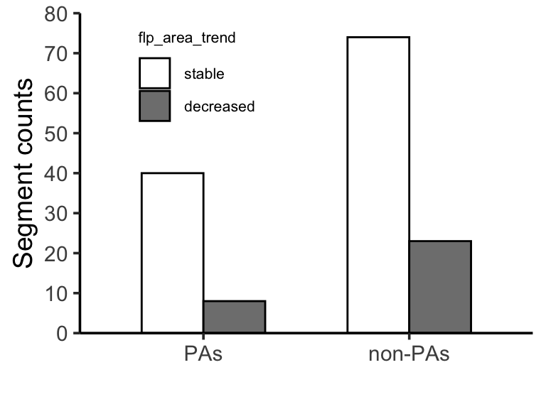

```r
trend_floodplain_compare <-
  ggplot(floodplain_df, aes(x = reserve_without_nj,
                          color = flp_area_trend, fill=flp_area_trend)) +
      geom_bar(stat = "count", width=0.6, position = position_dodge(), color="black") +
      scale_fill_manual(values = c("white", "grey50")) +
      scale_y_continuous(expand = c(0, 0), limits = c(0, 80), breaks=seq(0, 80, 10)) +
      scale_x_discrete(limits = c("Y", "N"),
                       breaks = c("Y", "N"),
                       labels = c("PAs", "non-PAs")) +
      labs (x = "", y = "Segment counts") +
      theme_classic(base_size = 14) +
      theme(legend.position = c(.1, .99),
            legend.justification = c("left", "top"),
            legend.box.just = "left",
            legend.title = element_text(size = 8),
            legend.text = element_text(size = 8))
trend_floodplain_compare
```

**Chi-square test**

```r
tbl_flp_trend <- table(floodplain_df$flp_area_trend, floodplain_df$reserve_without_nj)
tbl_flp_trend
```

```
             N  Y
  stable    74 40
  decreased 23  8
```

```r
chisq.test(tbl_flp_trend)
```

```
    Pearson's Chi-squared test with Yates' continuity correction

data:  tbl_flp_trend
X-squared = 0.57527, df = 1, p-value = 0.4482
```

The stable group actually contains 9 segments with increased floodplain areas, where 8 from non-PAs and 1 from PAs. We now remove them for chi square analysis (Appendix S5).

```r
tbl_flp_trend_remove_inc <- as.table(rbind(c(66, 39), c(23, 8)))
dimnames(tbl_flp_trend_remove_inc) <- list(group = c("stable", "decreased"),
                                           PA = c("N", "Y"))
tbl_flp_trend_remove_inc
```

```
           PA
group        N  Y
  stable    66 39
  decreased 23  8
```

```r
chisq.test(tbl_flp_trend_remove_inc)
```

```
    Pearson's Chi-squared test with Yates' continuity correction

data:  tbl_flp_trend_remove_inc
X-squared = 0.90497, df = 1, p-value = 0.3415
```

## 2. Examine if the PAs hold more river segments with stable cropland%

```r
seg_wise_cropland_df <- read.csv(file="../../data/analysis_outputs/trend_analysis/cropland_perc_regression_results.csv")
cropland_df <- seg_wise_cropland_df %>%
    mutate(groups = factor(groups, levels=group_lvls)) %>%
    mutate(group_levels = as.numeric(groups)) %>%
    mutate(crop_perc_trend = case_when((p_value < 0.05 & slope > 0) ~ "increased",
                             TRUE ~ "stable")) %>%
    mutate(crop_perc_trend = factor(crop_perc_trend,
                                    levels = c("stable", "increased"))) %>%
    mutate(reserve_without_nj = case_when(
        group_levels %in% c(22:30, 41:53, 88:104, 110:115, 139:141) ~ "Y",
        TRUE ~ "N")) %>%
    mutate(reserve_without_nj = as.factor(reserve_without_nj))
head(cropland_df, 5)
```

|  | groups | p_value | p_cate | r_squared | slope | group_levels | crop_perc_trend | reserve_without_nj |
| --- | --- | --- | --- | --- | --- | --- | --- | --- |
| 1 | [0,10) | 0.041 | <0.05 | 0.303 | -0.012 | 1 | stable | N |
| 2 | [10,20) | 0.016 | <0.05 | 0.393 | 0.024 | 2 | increased | N |
| 3 | [20,30) | 0.001 | <0.01 | 0.599 | 0.031 | 3 | increased | N |
| 4 | [30,40) | 0.003 | <0.01 | 0.527 | 0.024 | 4 | increased | N |
| 5 | [40,50) | 0.000 | <0.01 | 0.944 | 0.055 | 5 | increased | N |

**Plot the number of river segments of the PA and non-PA groups at each category** **of the cropland% trend.** (Fig. 5e)

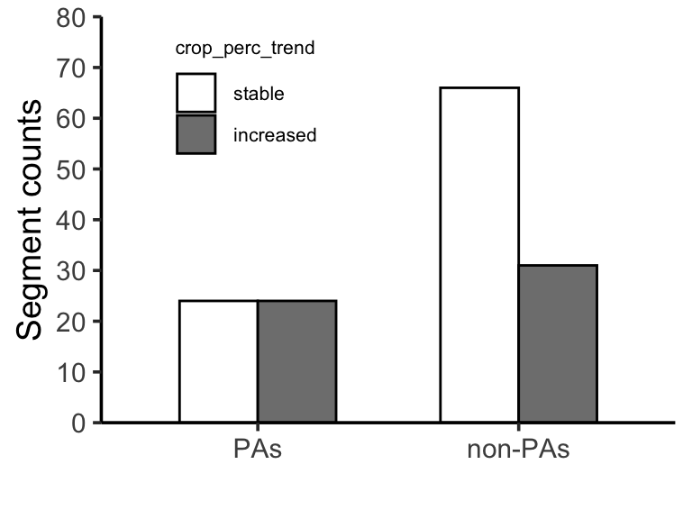

```r
trend_crop_perc_compare <-
  ggplot(cropland_df, aes(x=reserve_without_nj, color=crop_perc_trend, fill=crop_perc_trend)) +
      geom_bar(stat = "count", width=0.6, position = position_dodge(), color="black") +
      scale_fill_manual(values = c("white", "grey50")) +
      scale_y_continuous(expand = c(0, 0), limits = c(0, 80), breaks=seq(0, 80, 10)) +
      scale_x_discrete(limits = c("Y", "N"),
                       breaks = c("Y", "N"),
                       labels = c("PAs", "non-PAs")) +
      labs (x = "", y = "Segment counts") +
      theme_classic(base_size = 14) +
      theme(legend.position = c(.1, .99),
            legend.justification = c("left", "top"),
            legend.box.just = "left",
            legend.title = element_text(size = 8),
            legend.text = element_text(size = 8))
trend_crop_perc_compare
```

**Chi-square test**

```r
tbl_crop_trend <- table(cropland_df$crop_perc_trend, cropland_df$reserve_without_nj)
tbl_crop_trend
```

```
             N  Y
  stable    66 24
  increased 31 24
```

```r
chisq.test(tbl_crop_trend)
```

```
    Pearson's Chi-squared test with Yates' continuity correction

data:  tbl_crop_trend
X-squared = 3.706, df = 1, p-value = 0.05422
```

The stable group actually contains 4 segments with decreased cropland%, where all 4 from non-PAs. We now remove them for Chi square analysis (Appendix S5).

```r
tbl_crop_trend_remove_dec <- as.table(rbind(c(62, 24), c(31, 24)))
dimnames(tbl_crop_trend_remove_dec) <- list(group = c("stable", "increased"),
                                           PA = c("N", "Y"))
tbl_crop_trend_remove_dec
```

```
           PA
group        N  Y
  stable    62 24
  increased 31 24
```

```r
chisq.test(tbl_crop_trend_remove_dec)
```

```
    Pearson's Chi-squared test with Yates' continuity correction

data:  tbl_crop_trend_remove_dec
X-squared = 3.0291, df = 1, p-value = 0.08178
```

## 3. Examine if the PAs hold more river segments with lower urban development level

**Prepare the dataframe:** we grouped the “developed” and the “highly developed” as one category as “developed”, representing those river segments with relatively large urban% and large increment in urban% (see Appendix S3 for more details).

```r
seg_wise_urban_df <- read.csv(file="../../data/analysis_outputs/trend_analysis/urban_cluster_results.csv")

urban_df <- seg_wise_urban_df %>%
    mutate(groups = factor(groups, levels=group_lvls)) %>%
    mutate(group_levels = as.numeric(groups)) %>%
    droplevels() %>%
    mutate(urban_levels = case_when(
       development_levels=="less-developed" ~ "Less developed",
       development_levels=="fast-developing" ~ "Fast developing",
       TRUE ~ "Developed")) %>%
    mutate(urban_levels = factor(urban_levels,
       levels = c("Less developed", "Fast developing", "Developed"))) %>%
    mutate(reserve_without_nj = case_when(
        group_levels %in% c(22:30, 41:53, 88:104, 110:115, 139:141) ~ "Y",
        TRUE ~ "N")) %>%
    mutate(reserve_without_nj = as.factor(reserve_without_nj))
head(urban_df, 5)
```

|  | groups | intl | increment | incre_perc | development_levels | group_levels | urban_levels | reserve_without_nj |
| --- | --- | --- | --- | --- | --- | --- | --- | --- |
| 1 | [0,10) | 0.25474049 | 0.01845103 | 0.06753882 | less-developed | 1 | Less developed | N |
| 2 | [10,20) | 0.13140392 | 0.06991328 | 0.34727923 | less-developed | 2 | Less developed | N |
| 3 | [20,30) | 0.08342079 | 0.03018182 | 0.26567891 | less-developed | 3 | Less developed | N |
| 4 | [30,40) | 0.05295352 | 0.01665948 | 0.23931563 | less-developed | 4 | Less developed | N |
| 5 | [40,50) | 0.04399488 | 0.04033843 | 0.47832147 | fast-developing | 5 | Fast developing | N |

**Plot the number of river segments of the PA and non-PA groups at each category** **of the urban development levels.** (Fig. 5f)

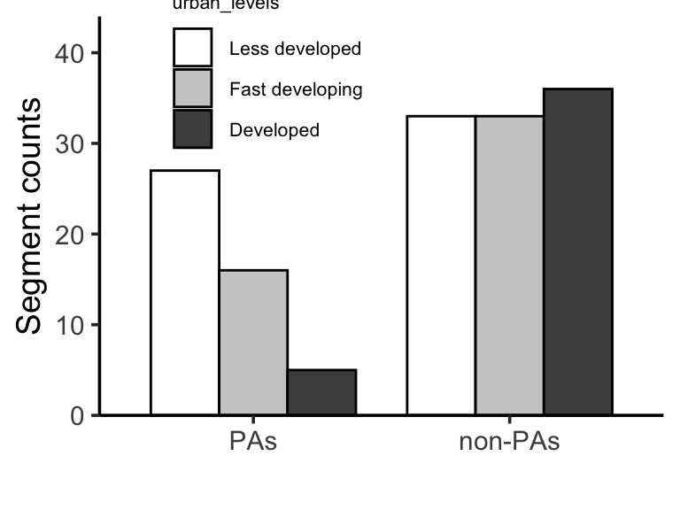

```r
trend_urban_levels_compare <-
  ggplot(urban_df, aes(x=reserve_without_nj, color=urban_levels, fill=urban_levels)) +
    geom_bar(stat = "count", width=0.8,
             position=position_dodge(preserve = "single"), color="black") +
    scale_fill_manual(values = c("white", "grey80", "grey30")) +
    scale_y_continuous(expand = c(0, 0), limits = c(0, 44), breaks=seq(0, 44, 10)) +
    scale_x_discrete(limits = c("Y", "N"),
                     breaks = c("Y", "N"),
                     labels = c("PAs", "non-PAs")) +
    labs (x = "", y = "Segment counts") +
    theme_classic(base_size = 14) +
    theme(legend.position = c(.1, 1.1),
          legend.justification = c("left", "top"),
          legend.box.just = "left",
          legend.title = element_text(size = 8),
          legend.text = element_text(size = 8))
trend_urban_levels_compare
```

**Chi-square test**

```r
tbl_urban_trend <- table(urban_df$urban_levels, urban_df$reserve_without_nj)
chisq.test(tbl_urban_trend)
```

```
    Pearson's Chi-squared test

data:  tbl_urban_trend
X-squared = 12.06, df = 2, p-value = 0.002406
```

**Post hoc pairwise comparisons**

Use the function `fisher.multcomp` in package `RVAideMemoire`.

```r
library(RVAideMemoire)
RVAideMemoire::fisher.multcomp(tbl_urban_trend, p.method = "bonferroni")
```

```
        Pairwise comparisons using Fisher's exact test for count data

data:  tbl_urban_trend

                Less developed Fast developing
Fast developing       0.714651               -
Developed             0.001428         0.07815

P value adjustment method: bonferroni
```

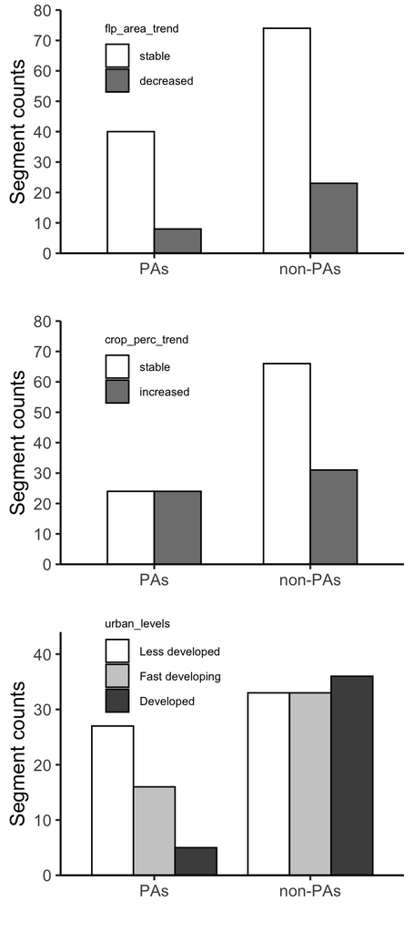

```r
combined_plot <- grid.arrange(trend_floodplain_compare,
                              trend_crop_perc_compare,
                              trend_urban_levels_compare,
                              nrow = 3)
```

```r
# ggsave("../../results/figures/fig_5d_f_habitat_changes.png", combined_plot, width = 4, height = 9)
```